# Projects

This is a repository of my previously completed assessments and data mining projects. The main idea is to represent career progression and exposure to the broad arena of data’s analytical theory and methods.

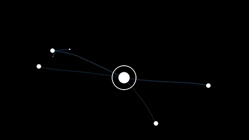

##### Welcome To My Projects

data science

analytics

ML

AI

This is my portfolio as a data professional

Oscar Cardec

Jul 1, 2024

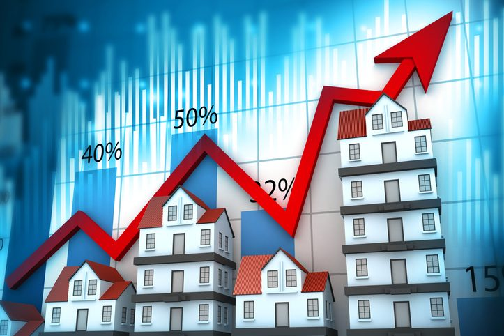

##### House Market Analysis - Regression Model

random forest

regression

Oscar Cardec

Jul 21, 2022

[figure not shown]

##### Aicraft’s Lateral Deviation - Part 2

svm

naïve bayes

gbm

knn

ctree

rpart

Assessment of different classification algorithms and their respective results

Oscar Cardec

Nov 13, 2021

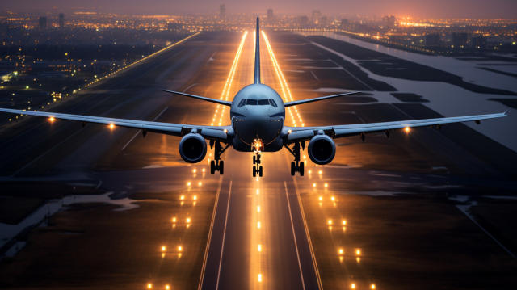

##### Aicraft’s Lateral Deviation - Part 1

EDA

ETL

data

distribution

sample

Oscar Cardec

Nov 12, 2021

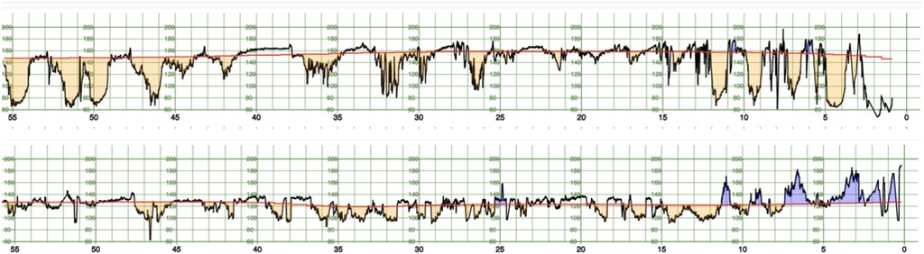

##### Conditional Inference Trees

ctree

decision tree

classification

Supervised learning classifications using the R package **partykit** conditional inference trees

Oscar Cardec

Oct 22, 2020

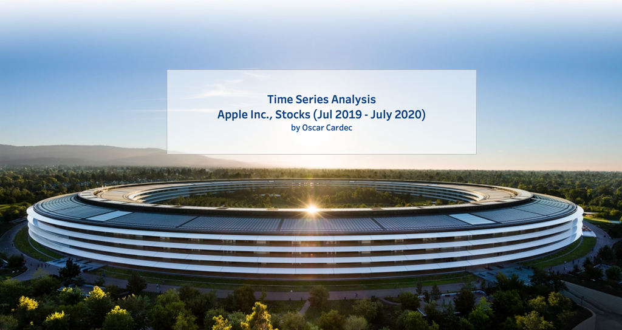

##### Time Series Analysis - AAPL

time series

forecasting

The following is a basic time series analysis of Apple, Inc. stock market between July 2019 and July 2020.

Oscar Cardec

Jul 15, 2020

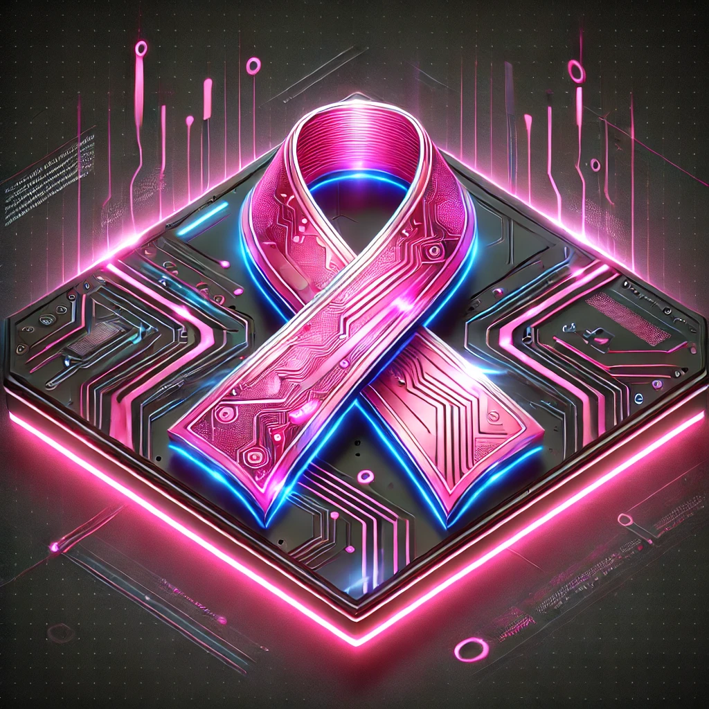

##### Cancerous Cells Classification - Neural Network

neural network

classification

pca

ctree

rocr

splom

Malignant cells classification across digitized images of fine needle aspirate (FNA) of a breast mass 3-dimensional fragmentated samples

Oscar Cardec

Jun 21, 2020

[figure not shown]

##### Geospatial Analysis Infographic

tableau

infographic

geospatial

GDP analysis across Middle East (FY 2020)

Oscar Cardec

Apr 13, 2020

[figure not shown]

##### Join the Alliance

infographic

tableau

Oscar Cardec

Mar 26, 2020